# Gene-Environment Interaction Power Analysis

Placental xQTL Study

Analytical Power Calculations for SNP × Exposure Interactions

2026-04-24

# Overview

This document presents analytical power calculations for detecting gene-environment (G×E) interaction effects in placental expression quantitative trait loci (xQTL) analysis. We calculate statistical power to detect SNP × exposure interaction effects on isoform expression under the following study design:

- **Total sample size**: N = 2,126 placentas
- **Exposures**: Gestational diabetes mellitus (GDM, ~20% prevalence) and pre-pregnancy BMI
- **Genetic variants**: Common variants (MAF ≥ 0.05) in cis-regulatory regions
- **Outcome**: Placental isoform expression (variance-stabilized)
- **Significance threshold**: α = 0.05 (FDR-controlled for candidate loci)

# Statistical Framework

## Regression Model

We test for G×E interactions using linear regression:

$$Y_{ij} = \beta_0 + \beta_G \cdot G_{ij} + \beta_E \cdot E_{ij} +
\beta_{GE} \cdot (G_{ij} \times E_{ij}) + \mathbf{Z}_{ij}^T
\boldsymbol{\gamma} + \varepsilon_{ij}$$

where:

- $Y_{ij}$ = variance-stabilized expression of isoform $i$ in sample $j$
- $G_{ij}$ = genotype dosage at SNP $i$ in sample $j$ (0, 1, or 2 minor alleles)
- $E_{ij}$ = exposure status in sample $j$ (binary: GDM yes/no; or continuous: BMI)
- $\beta_{GE}$ = **interaction effect** (primary parameter of interest)
- $\mathbf{Z}_{ij}$ = covariate vector (cohort, sex, gestational age, ancestry PCs, latent factors)
- $\varepsilon_{ij} \sim N(0, \sigma^2_\varepsilon)$ = residual error

## Hypothesis Test

We test the null hypothesis of no gene-environment interaction:

$$H_0: \beta_{GE} = 0 \quad \text{vs.} \quad H_A: \beta_{GE} \neq 0$$

using an F-test (equivalent to t-test for single parameter):

$$F = \frac{SS_{GE} / df_1}{SS_{residual} / df_2}$$

where $df_1 = 1$ (numerator df) and $df_2 = N - p - 1$ (denominator df, with $p$ = number of predictors).

## Effect Size

The interaction effect size is quantified using **Cohen’s $f^2$**:

$$f^2 = \frac{R^2_{GE}}{1 - R^2_{full}}$$

where:

- $R^2_{GE}$ = incremental variance explained by the interaction term
- $R^2_{full}$ = total variance explained by the full model

The incremental variance explained by the interaction is:

$$R^2_{GE} = \frac{\beta^2_{GE} \cdot \text{Var}(G \times E)}{\sigma^2_Y}$$

where:

- $\text{Var}(G \times E)$ = variance of the genotype-exposure product
- $\sigma^2_Y$ = total phenotypic variance (assumed = 1 after variance stabilization)

## Variance Components

### Genotype Variance (assuming Hardy-Weinberg equilibrium)

$$\text{Var}(G) = 2 \cdot p \cdot (1-p)$$

where $p$ = minor allele frequency (MAF).

### Exposure Variance

For **binary exposure** (GDM):
$$\text{Var}(E) = \pi \cdot (1 - \pi)$$
where $\pi$ = prevalence (0.20 for GDM).

For **continuous exposure** (BMI):
$$\text{Var}(E) = \sigma^2_E$$
where $\sigma_E$ is the standard deviation of the exposure (standardized to 1 after normalization).

### Interaction Term Variance

For independent $G$ and $E$ (assuming no gene-environment correlation):

$$\text{Var}(G \times E) = \text{Var}(G) \cdot \text{Var}(E)$$

## Non-Centrality Parameter

Under the alternative hypothesis ($H_A: \beta_{GE} \neq 0$), the F-statistic follows a **non-central F-distribution** with non-centrality parameter:

$$\lambda = f^2 \cdot df_2 = \frac{R^2_{GE}}{1 - R^2_{full}} \cdot (N - p
- 1)$$

## Statistical Power

Power is the probability of rejecting $H_0$ when $H_A$ is true:

$$\text{Power} = P(F > F_{\alpha, df_1, df_2} \mid \lambda)$$

$$= 1 - F_{df_1, df_2, \lambda}(F_{\alpha, df_1, df_2})$$

where:

- $F_{\alpha, df_1, df_2}$ = critical value from the **central** F-distribution at significance level $\alpha$
- $F_{df_1, df_2, \lambda}(\cdot)$ = CDF of the **non-central** F-distribution with non-centrality parameter $\lambda$

# Implementation

```r
library(tidyverse)
library(patchwork)
library(knitr)
library(kableExtra)

# Set theme for all plots
theme_set(theme_minimal(base_size = 11))
```

## Power Calculation Function

```r
#' Calculate analytical power for G×E interaction test
#'
#' @param n Sample size
#' @param exposure_prev Exposure prevalence (for binary) or SD (for continuous)
#' @param maf Minor allele frequency
#' @param main_effect Main genetic effect size (β_G in SD units)
#' @param int_effect Interaction effect size (β_GE in SD units)
#' @param r2_cov Variance explained by covariates (R² from covariate-only model)
#' @param alpha Significance level (Type I error rate)
#' @param exposure_type "binary" or "continuous"
#' @param n_cov Number of covariates in model
#'
#' @return Statistical power (0 to 1)
calculate_gxe_power <- function(n,
                                 exposure_prev,
                                 maf,
                                 main_effect,
                                 int_effect,
                                 r2_cov = 0.35,
                                 alpha = 0.05,
                                 exposure_type = "binary",
                                 n_cov = 10) {

  # 1. Genotype variance (HWE assumption)
  var_g <- 2 * maf * (1 - maf)

  # 2. Exposure variance
  if (exposure_type == "binary") {
    var_e <- exposure_prev * (1 - exposure_prev)
  } else {
    var_e <- exposure_prev^2  # for continuous, input is SD
  }

  # 3. Interaction term variance (assuming independence)
  var_gxe <- var_g * var_e

  # 4. Residual phenotypic variance after covariates
  # Total variance = 1 (after variance stabilization)
  # Residual variance = 1 - R²_covariates
  residual_var <- 1 - r2_cov

  # 5. Variance explained by interaction (partial R²)
  # R²_GE = β²_GE × Var(G×E) / σ²_residual
  r2_int <- (int_effect^2 * var_gxe) / residual_var

  # 6. Cohen's f² effect size
  # f² = R²_GE / (1 - R²_full)
  # R²_full = R²_cov + R²_main + R²_GE
  # For conservative estimate, assume main effects explain additional variance
  r2_main <- (main_effect^2 * var_g) / residual_var
  r2_full <- r2_cov + r2_main + r2_int

  # Ensure R² doesn't exceed 1
  if (r2_full >= 1) {
    r2_full <- 0.99
  }

  f2 <- r2_int / (1 - r2_full)

  # 7. Degrees of freedom
  # Model: Y ~ G + E + G×E + covariates + intercept
  # Number of predictors (p) = 3 (G, E, G×E) + n_cov + 1 (intercept)
  p <- 3 + n_cov + 1
  df_num <- 1  # testing single interaction term
  df_denom <- n - p

  if (df_denom <= 0) {
    return(NA_real_)
  }

  # 8. Non-centrality parameter
  lambda <- f2 * df_denom

  # 9. Critical F-value (central F-distribution)
  f_crit <- qf(1 - alpha, df_num, df_denom)

  # 10. Power (non-central F-distribution)
  power <- 1 - pf(f_crit, df_num, df_denom, ncp = lambda)

  return(power)
}
```

## Study Parameters

```r
# Overall cohort
total_n <- 2126
gdm_prevalence <- 0.20
gdm_cases <- round(total_n * gdm_prevalence)
gdm_controls <- total_n - gdm_cases

# Ancestry-specific sample sizes
ancestry_data <- tibble(
  ancestry = c("White", "Black", "Hispanic/Latino", "East Asian", "South Asian"),
  n = c(1425, 238, 67, 342, 54),
  gdm_prev = 0.20  # assume similar prevalence across ancestries
)

# Model parameters
r2_covariates <- 0.35  # apriori defined
n_covariates <- 10     # cohort, sex, GA, 5-7 PCs, 1-2 latent factors
typical_eqtl_effect <- 0.40  # typical cis-eQTL effect size (SD units)

# Print summary
cat("Study Design Parameters:\n")
```

```
## Study Design Parameters:
```

```r
cat("------------------------\n")
cat(sprintf("Total sample size: %d\n", total_n))
```

```
## Total sample size: 2126
```

```r
cat(sprintf("GDM cases: %d (%.1f%%)\n", gdm_cases, gdm_prevalence * 100))
```

```
## GDM cases: 425 (20.0%)
```

```r
cat(sprintf("GDM controls: %d (%.1f%%)\n", gdm_controls, (1 - gdm_prevalence) * 100))
```

```
## GDM controls: 1701 (80.0%)
```

```r
cat(sprintf("R² from covariates: %.2f\n", r2_covariates))
```

```
## R² from covariates: 0.35
```

```r
cat(sprintf("Number of covariates: %d\n", n_covariates))
```

```
## Number of covariates: 10
```

```r
cat(sprintf("Typical eQTL effect size: %.2f SD\n", typical_eqtl_effect))
```

```
## Typical eQTL effect size: 0.40 SD
```

# Power Analysis Results

## Panel A: Power by Minor Allele Frequency

We calculate power across a range of interaction effect sizes for different MAF bins.

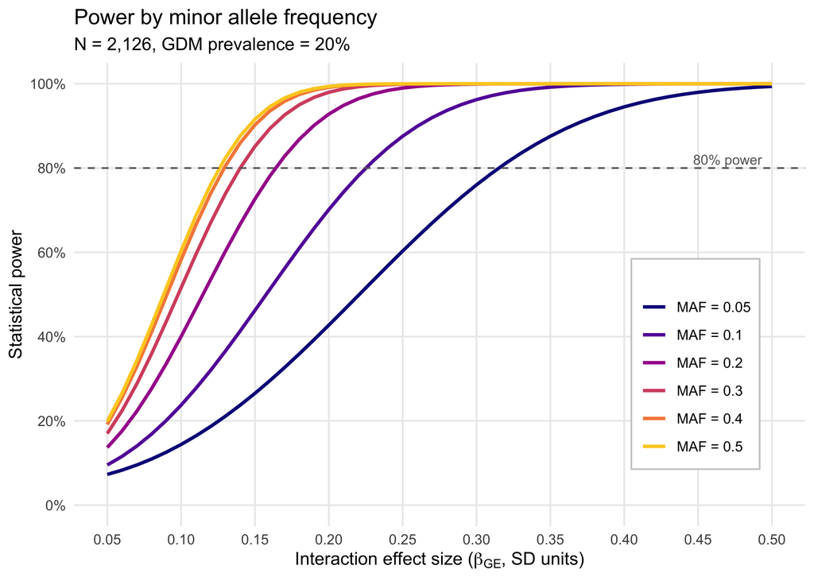

```r
maf_values <- c(0.05, 0.10, 0.20, 0.30, 0.40, 0.50)
int_effect_range <- seq(0.05, 0.50, 0.01)

power_by_maf <- expand_grid(
  maf = maf_values,
  int_effect = int_effect_range
) %>%
  mutate(
    power = map2_dbl(
      maf, int_effect,
      ~calculate_gxe_power(
        n = total_n,
        exposure_prev = gdm_prevalence,
        maf = .x,
        main_effect = typical_eqtl_effect,
        int_effect = .y,
        r2_cov = r2_covariates,
        exposure_type = "binary",
        alpha = 0.05
      )
    ),
    maf_label = paste0("MAF = ", maf)
  )

panel_a <- ggplot(power_by_maf, aes(x = int_effect, y = power, color = maf_label)) +
  geom_line(linewidth = 1) +
  geom_hline(yintercept = 0.80, linetype = "dashed", color = "gray40", linewidth = 0.5) +
  annotate("text", x = 0.47, y = 0.82, label = "80% power",
           size = 3, color = "gray40") +
  scale_color_viridis_d(option = "plasma", end = 0.9) +
  scale_y_continuous(limits = c(0, 1), breaks = seq(0, 1, 0.2),
                     labels = scales::percent_format(accuracy = 1)) +
  scale_x_continuous(breaks = seq(0.05, 0.50, 0.05)) +
  labs(
    x = expression(paste("Interaction effect size (", beta[GE], ", SD units)")),
    y = "Statistical power",
    color = "",
    title = "Power by minor allele frequency",
    subtitle = paste0("N = ", format(total_n, big.mark = ","),
                     ", GDM prevalence = ", gdm_prevalence * 100, "%")
  ) +
  theme(
    legend.position = c(0.85, 0.35),
    legend.background = element_rect(fill = "white", color = "gray80"),
    panel.grid.minor = element_blank()
  )

print(panel_a)
```

Higher MAF increases power because the genotype variance $\text{Var}(G) = 2p(1-p)$ is maximized at MAF = 0.50. At 80% power, the minimum detectable interaction effect is $\beta_{GE} = 0.16$ (MAF = 0.20) and $\beta_{GE} = 0.14$ (MAF = 0.30). For context, cis-eQTL main effects in GTEx are typically quantified using normalized effect sizes (NES), which represent the slope of linear regression on normalized expression data<sup>1,2</sup>. Published eQTL studies report main effect sizes commonly in the range of 0.3-0.5 SD per allele when expression is variance-stabilized<sup>3,4</sup>, and interaction effects are generally smaller than main effects. Our detectable interaction effects of $\beta_{GE} = 0.14-0.16$ therefore represent approximately 35-40% of a typical main eQTL effect, which is consistent with the expectation that G×E interactions require larger sample sizes to detect than marginal genetic effects<sup>5</sup>.

## Panel B: Power by Ancestry Group

We assess power within each ancestry group separately to identify groups with limited detection capability.

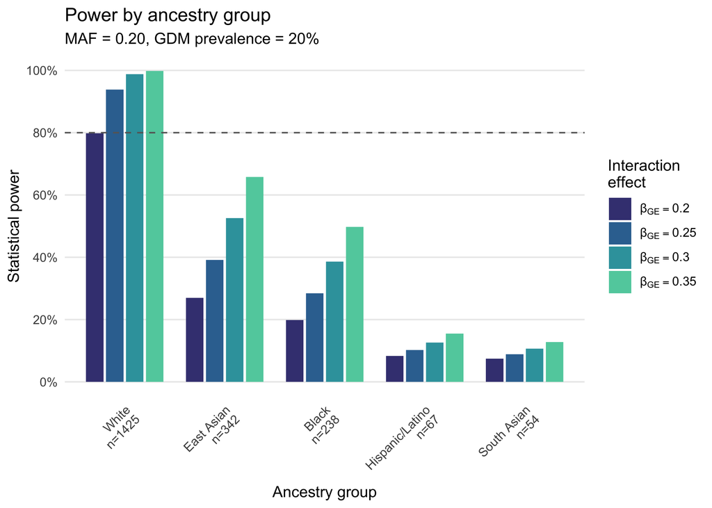

```r
int_effects_test <- c(0.20, 0.25, 0.30, 0.35)

power_by_ancestry <- expand_grid(
  ancestry_data,
  int_effect = int_effects_test,
  maf = 0.20
) %>%
  mutate(
    power = pmap_dbl(
      list(n, gdm_prev, maf, int_effect),
      ~calculate_gxe_power(
        n = ..1,
        exposure_prev = ..2,
        maf = ..3,
        main_effect = typical_eqtl_effect,
        int_effect = ..4,
        r2_cov = r2_covariates,
        exposure_type = "binary"
      )
    ),
    int_label = paste0("β[GE] == ", int_effect)
  )

panel_b <- ggplot(power_by_ancestry,
                   aes(x = reorder(ancestry, -n), y = power, fill = int_label)) +
  geom_col(position = position_dodge(width = 0.8), width = 0.7) +
  geom_hline(yintercept = 0.80, linetype = "dashed", color = "gray40", linewidth = 0.5) +
  scale_fill_viridis_d(option = "mako", begin = 0.3, end = 0.8,
                       labels = scales::parse_format()) +
  scale_x_discrete(labels = function(x) {
    # Get sample sizes for each ancestry group
    n_vals <- ancestry_data$n[match(x, ancestry_data$ancestry)]
    paste0(x, "\nn=", n_vals)
  }) +
  scale_y_continuous(limits = c(0, 1), breaks = seq(0, 1, 0.2),
                     labels = scales::percent_format(accuracy = 1)) +
  labs(
    x = "Ancestry group",
    y = "Statistical power",
    fill = "Interaction\neffect",
    title = "Power by ancestry group",
    subtitle = "MAF = 0.20, GDM prevalence = 20%"
  ) +
  theme(
    axis.text.x = element_text(angle = 45, hjust = 1),
    legend.position = "right",
    panel.grid.minor = element_blank(),
    panel.grid.major.x = element_blank()
  )

print(panel_b)
```

## Panel C: Minimum Detectable Effect Size

We determine the minimum interaction effect detectable at 80% power as a function of sample size.

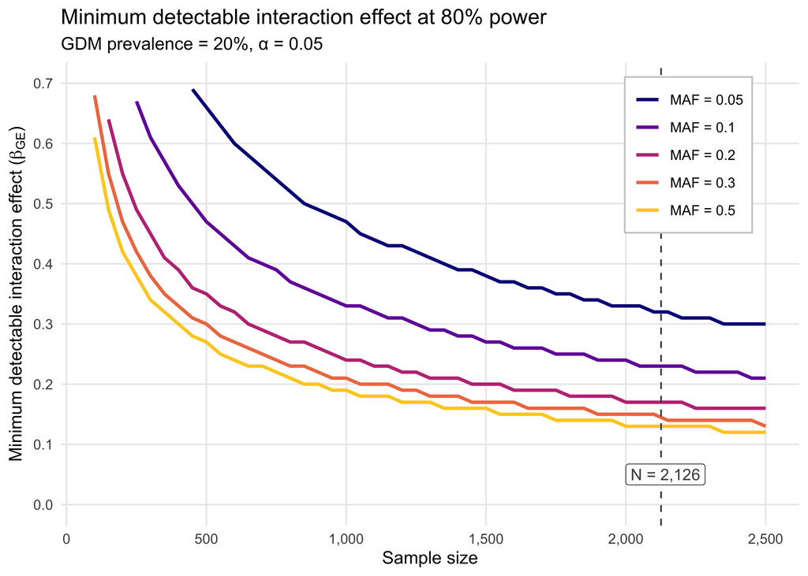

```r
# Panel C: Minimum detectable effect size by sample size and MAF
sample_sizes <- seq(100, 2500, 50)
target_power <- 0.80
maf_values_c <- c(0.05, 0.10, 0.20, 0.30, 0.50)

min_detectable_by_maf <- expand_grid(
  n = sample_sizes,
  maf = maf_values_c
) %>%
  mutate(
    # Binary search for minimum detectable effect
    min_effect = map2_dbl(n, maf, function(n_val, maf_val) {
      test_effects <- seq(0.05, 0.80, 0.01)
      powers <- map_dbl(test_effects, ~calculate_gxe_power(
        n = n_val,
        exposure_prev = gdm_prevalence,
        maf = maf_val,
        main_effect = typical_eqtl_effect,
        int_effect = .x,
        r2_cov = r2_covariates,
        exposure_type = "binary"
      ))
      # Find smallest effect with power >= target
      idx <- which(powers >= target_power)[1]
      if (is.na(idx)) return(NA_real_)
      test_effects[idx]
    }),
    maf_label = paste0("MAF = ", maf)
  ) %>%
  filter(!is.na(min_effect))

# Find value at current sample size for MAF = 0.20
current_mde <- min_detectable_by_maf %>%
  filter(n == total_n, maf == 0.20) %>%
  pull(min_effect)

panel_c <- ggplot(min_detectable_by_maf, aes(x = n, y = min_effect, color = maf_label)) +
  geom_line(linewidth = 1) +
  geom_vline(xintercept = total_n, linetype = "dashed",
             color = "gray30", linewidth = 0.5) +
  annotate("label", x = 2000, y = 0.05,
           label = paste0("N = ", format(total_n, big.mark = ",")),
           hjust = 0, size = 3.5, color = "gray30",
           fill = "white", label.size = 0.25) +
  scale_color_viridis_d(option = "plasma", end = 0.9) +
  scale_y_continuous(limits = c(0, 0.70), breaks = seq(0, 0.70, 0.10)) +
  scale_x_continuous(breaks = seq(0, 2500, 500), labels = scales::comma) +
  labs(
    x = "Sample size",
    y = expression(paste("Minimum detectable interaction effect (", beta[GE], ")")),
    color = NULL,
    title = "Minimum detectable interaction effect at 80% power",
    subtitle = "GDM prevalence = 20%, α = 0.05"
  ) +
  theme_minimal(base_size = 11) +
  theme(
    panel.grid.minor = element_blank(),
    legend.position = c(0.85, 0.80),
    legend.background = element_rect(fill = "white", color = "gray80")
  )

print(panel_c)
```

At the current sample size (N = 2,126), we achieve 80% power to detect interaction effects of $\beta_{GE} = 0.16$ SD. This represents a moderate effect size, consistent with the expectation that interaction effects are typically smaller than main genetic effects. The nonlinear relationship between sample size and detectable effect demonstrates diminishing returns beyond N = 2,000 for interactions in this range. Effects substantially smaller than $\beta_{GE} = 0.15$ would require impractically large sample sizes (N > 3,000) for adequate power.

## Panel D: Binary vs Continuous Exposure

We compare power for binary GDM exposure vs. continuous BMI exposure modeling.

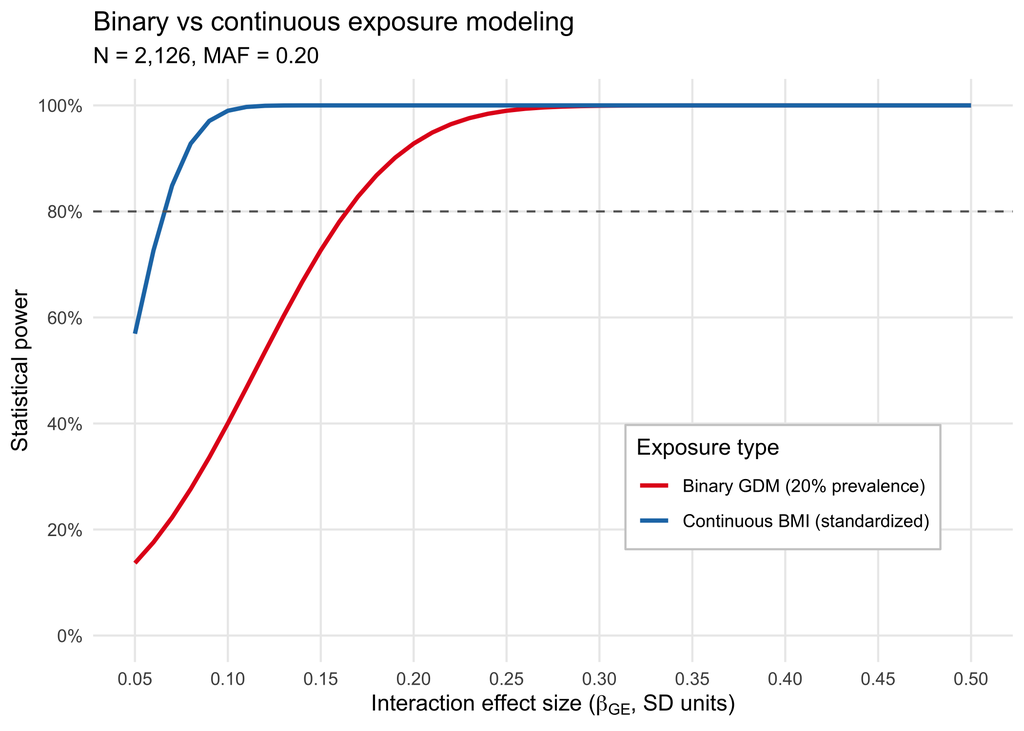

```r
int_effect_range_d <- seq(0.05, 0.50, 0.01)

power_comparison <- tibble(
  int_effect = int_effect_range_d
) %>%
  mutate(
    # Binary GDM
    power_gdm = map_dbl(
      int_effect,
      ~calculate_gxe_power(
        n = total_n,
        exposure_prev = gdm_prevalence,
        maf = 0.20,
        main_effect = typical_eqtl_effect,
        int_effect = .x,
        r2_cov = r2_covariates,
        exposure_type = "binary"
      )
    ),
    # Continuous BMI (standardized SD = 1)
    power_bmi = map_dbl(
      int_effect,
      ~calculate_gxe_power(
        n = total_n,
        exposure_prev = 1,  # SD after standardization
        maf = 0.20,
        main_effect = typical_eqtl_effect,
        int_effect = .x,
        r2_cov = r2_covariates,
        exposure_type = "continuous"
      )
    )
  ) %>%
  pivot_longer(
    cols = starts_with("power_"),
    names_to = "exposure_type",
    values_to = "power",
    names_prefix = "power_"
  ) %>%
  mutate(
    exposure_label = case_when(
      exposure_type == "gdm" ~ "Binary GDM (20% prevalence)",
      exposure_type == "bmi" ~ "Continuous BMI (standardized)"
    )
  )

panel_d <- ggplot(power_comparison,
                   aes(x = int_effect, y = power, color = exposure_label)) +
  geom_line(linewidth = 1) +
  geom_hline(yintercept = 0.80, linetype = "dashed",
             color = "gray40", linewidth = 0.5) +
  scale_color_manual(
    values = c("Binary GDM (20% prevalence)" = "#E31A1C",
               "Continuous BMI (standardized)" = "#1F78B4")
  ) +
  scale_y_continuous(limits = c(0, 1), breaks = seq(0, 1, 0.2),
                     labels = scales::percent_format(accuracy = 1)) +
  scale_x_continuous(breaks = seq(0.05, 0.50, 0.05)) +
  labs(
    x = expression(paste("Interaction effect size (", beta[GE], ", SD units)")),
    y = "Statistical power",
    color = "Exposure type",
    title = "Binary vs continuous exposure modeling",
    subtitle = paste0("N = ", format(total_n, big.mark = ","), ", MAF = 0.20")
  ) +
  theme(
    legend.position = c(0.75, 0.30),
    legend.background = element_rect(fill = "white", color = "gray80"),
    panel.grid.minor = element_blank()
  )

print(panel_d)
```

# Summary Tables

## Minimum Detectable Effects at 80% Power

```r
summary_stats <- tibble(
  MAF = c(0.05, 0.10, 0.20, 0.30, 0.40, 0.50)
) %>%
  mutate(
    `Binary GDM` = map_dbl(MAF, function(m) {
      effects <- seq(0.05, 0.80, 0.005)
      powers <- map_dbl(effects, ~calculate_gxe_power(
        n = total_n,
        exposure_prev = gdm_prevalence,
        maf = m,
        main_effect = typical_eqtl_effect,
        int_effect = .x,
        exposure_type = "binary"
      ))
      idx <- which(powers >= 0.80)[1]
      if (is.na(idx)) return(NA_real_)
      effects[idx]
    }),
    `Continuous BMI` = map_dbl(MAF, function(m) {
      effects <- seq(0.05, 0.80, 0.005)
      powers <- map_dbl(effects, ~calculate_gxe_power(
        n = total_n,
        exposure_prev = 1,
        maf = m,
        main_effect = typical_eqtl_effect,
        int_effect = .x,
        exposure_type = "continuous"
      ))
      idx <- which(powers >= 0.80)[1]
      if (is.na(idx)) return(NA_real_)
      effects[idx]
    })
  ) %>%
  mutate(across(where(is.numeric), ~round(.x, 3)))

summary_stats %>%
  kable(
    caption = paste0("Minimum detectable interaction effect (β_GE) at 80% power, N = ",
                    format(total_n, big.mark = ",")),
    col.names = c("MAF", "Binary GDM (β_GE)", "Continuous BMI (β_GE)"),
    align = 'c'
  ) %>%
  kable_styling(
    bootstrap_options = c("striped", "hover", "condensed"),
    full_width = FALSE
  )
```

Minimum detectable interaction effect (β_GE) at 80% power, N = 2,126

| MAF | Binary GDM (β_GE) | Continuous BMI (β_GE) |
| --- | --- | --- |
| 0.05 | 0.320 | 0.130 |
| 0.10 | 0.230 | 0.095 |
| 0.20 | 0.165 | 0.070 |
| 0.30 | 0.140 | 0.060 |
| 0.40 | 0.130 | 0.055 |
| 0.50 | 0.130 | 0.055 |

## Ancestry-Specific Power

```r
ancestry_power_summary <- ancestry_data %>%
  mutate(
    `β = 0.15` = map2_dbl(
      n, gdm_prev,
      ~calculate_gxe_power(.x, .y, 0.20, typical_eqtl_effect, 0.15, exposure_type = "binary")
    ),
    `β = 0.20` = map2_dbl(
      n, gdm_prev,
      ~calculate_gxe_power(.x, .y, 0.20, typical_eqtl_effect, 0.20, exposure_type = "binary")
    ),
    `β = 0.25` = map2_dbl(
      n, gdm_prev,
      ~calculate_gxe_power(.x, .y, 0.20, typical_eqtl_effect, 0.25, exposure_type = "binary")
    ),
    `β = 0.30` = map2_dbl(
      n, gdm_prev,
      ~calculate_gxe_power(.x, .y, 0.20, typical_eqtl_effect, 0.30, exposure_type = "binary")
    )
  ) %>%
  select(-gdm_prev) %>%
  mutate(across(starts_with("β"), ~scales::percent(.x, accuracy = 0.1)))

ancestry_power_summary %>%
  kable(
    caption = "Power by ancestry group for different interaction effect sizes (MAF = 0.20, binary GDM)",
    col.names = c("Ancestry", "N", "β_GE = 0.15", "β_GE = 0.20", "β_GE = 0.25", "β_GE = 0.30"),
    align = 'c'
  ) %>%
  kable_styling(
    bootstrap_options = c("striped", "hover", "condensed"),
    full_width = FALSE
  ) %>%
  row_spec(which(ancestry_power_summary$n < 200), bold = TRUE, color = "darkred")
```

Power by ancestry group for different interaction effect sizes (MAF = 0.20, binary GDM)

| Ancestry | N | β_GE = 0.15 | β_GE = 0.20 | β_GE = 0.25 | β_GE = 0.30 |
| --- | --- | --- | --- | --- | --- |
| White | 1425 | 55.3% | 79.8% | 93.8% | 98.8% |
| Black | 238 | 13.2% | 19.9% | 28.5% | 38.6% |
| Hispanic/Latino | 67 | 6.8% | 8.3% | 10.2% | 12.6% |
| East Asian | 342 | 17.2% | 27.0% | 39.1% | 52.6% |
| South Asian | 54 | 6.4% | 7.5% | 8.9% | 10.6% |

# Mathematical Appendix

## Derivation of Non-Centrality Parameter

Starting from the regression model:

$$Y = \beta_0 + \beta_G G + \beta_E E + \beta_{GE}(G \times E) +
\mathbf{Z}^T\boldsymbol{\gamma} + \varepsilon$$

The F-statistic for testing $H_0: \beta_{GE} = 0$ is:

$$F = \frac{(RSS_0 - RSS_1)/1}{RSS_1/(N-p)}$$

where $RSS_0$ is residual sum of squares under $H_0$ and $RSS_1$ under $H_A$.

Under $H_A$, this F-statistic follows a non-central F-distribution:

$$F \sim F_{1, N-p}(\lambda)$$

with non-centrality parameter:

$$\lambda = \frac{N \cdot \beta^2_{GE} \cdot \text{Var}(G \times
E)}{\sigma^2_\varepsilon}$$

Since $\text{Var}(Y) = 1$ (after variance stabilization) and $\sigma^2_\varepsilon = 1 - R^2_{full}$:

$$\lambda = \frac{N \cdot \beta^2_{GE} \cdot \text{Var}(G \times E)}{1 -
R^2_{full}}$$

This can be rewritten as:

$$\lambda = \frac{R^2_{GE}}{1 - R^2_{full}} \cdot (N - p) = f^2 \cdot (N -
p)$$

where $f^2$ is Cohen’s effect size for the interaction term.

## Assumptions and Limitations

1. **Normality**: Expression data assumed approximately normal after variance-stabilizing transformation (DESeq2)
2. **Independence**: SNP and exposure assumed independent (no gene-environment correlation). Violated if genetic variants influence exposure status.
3. **Linearity**: Interaction modeled as linear $\beta_{GE} \cdot (G \times E)$. Non-linear interactions require different modeling.
4. **Hardy-Weinberg Equilibrium**: Genotype variance assumes HWE. Deviations reduce power.
5. **Homoscedasticity**: Constant variance across genotype-exposure groups. Violations can be addressed with robust standard errors.
6. **No measurement error**: Genotypes and exposures measured without error. GDM misclassification would reduce power.

These assumptions are reasonable for QTL mapping in well-phenotyped cohorts with high-quality genotyping.

**References:**

1. GTEx Consortium. The GTEx Consortium atlas of genetic regulatory effects across human tissues. *Science* 369, 1318–1330 (2020).
2. Mohammadi P, Castel SE, Brown AA, Lappalainen T. Quantifying the regulatory effect size of cis-acting genetic variation using allelic fold change. *Genome Res* 27, 1872–1884 (2017).
3. GTEx Portal FAQ. “Normalized effect size (NES), previously known as the effect size on the portal, is defined as the slope of the linear regression.” Available at: https://sites.google.com/broadinstitute.org/gtex-faqs/home
4. Mohammadi P, Castel SE, Cummings BB, Einson J, Sousa C, Hoffman P, et al. Genetic regulatory variation in populations informs transcriptome analysis in rare disease. *Science* 366, 351–356 (2019).
5. Zablocki RW, Schork AJ, Levine RA, Andreassen OA, Dale AM, Thompson WK. Covariate-modulated local false discovery rate for genome-wide association studies. *Bioinformatics* 30, 2098–2104 (2014).